# Randomized Experiment

Stratified Randomized Experiments

Last Update: 2024-02-22

# 1 Generating simulated data

## 1.1 Setting constants and parameters

We consider a stratified randomized experiment with two strata. First, we fix the seed and set the number of individuals `N`, the proportion of individuals in the two strata `q`, the propensity scores `e` in the two strata, and the size of the treatment group `N_1`.

```r
set.seed(1)
N <- 2000
R <- 1000
q <- c(0.6, 0.4)
e <- c(0.3, 0.7)
N_1 <- N * q * e
```

Next, we set the population average treatment effect `tau_population` in the two strata.

```r
tau_population <-
  c(
    0.2,
    0.3
  )
```

## 1.2 Generating potential outcomes

We generate the potential outcomes for the sample. This operation corresponds to one random draw. We also calculate the average treatment effect `tau` in the sample.

```r
outcome_potential <-
  1:2 %>%
  purrr::map(
    function(g) {
      tibble::tibble(
        g = g,
        y_0 =
          rnorm(
            N * q[g],
            mean = 0,
            sd = 0.1
          ),
        y_1 =
          rnorm(
            N * q[g],
            mean = tau_population[g],
            sd = 0.1
          )
      )
    }
  ) %>%
  dplyr::bind_rows()

tau <-
  outcome_potential %>%
  dplyr::group_by(g) %>%
  dplyr::summarise(
    tau = mean(y_1 - y_0)
  ) %>%
  dplyr::pull(tau)

outcome_potential %>%
  head() %>%
  kbl() %>%
  kable_styling()
```

| g | y_0 | y_1 |
| --- | --- | --- |
| 1 | -0.0626454 | 0.0442964 |
| 1 | 0.0183643 | 0.3923164 |
| 1 | -0.0835629 | 0.0143170 |
| 1 | 0.1595281 | -0.0106118 |
| 1 | 0.0329508 | 0.2697649 |
| 1 | -0.0820468 | 0.2907444 |

```r
outcome_potential %>%
  modelsummary::datasummary_skim()
```

Unique (#)

Missing (%)

Mean

SD

Min

Median

Max

g

2

0

1.4

0.5

1.0

1.0

2.0

y_0

2000

0

0.0

0.1

−0.4

−0.0

0.4

[figure not shown]

y_1

2000

0

0.2

0.1

−0.1

0.2

0.6

[figure not shown]

```r
tau
```

```
## [1] 0.2022689 0.2935481
```

Next, we generate the observed data. First, we generate the treatment vector `z`. This operation corresponds to one randomized experiment. We then calculate the realized outcomes based on the realized treatment vector and potential outcomes. The resulting `data_realized` is the observed data.

```r
data_realized <-
  AppliedEconometricsCode::generate_data_stratified(
    outcome_potential = outcome_potential,
    N_1 = N_1,
    seed = 1
  )
data_realized %>%
  head() %>%
  kbl() %>%
  kable_styling()
```

| g | z | y |
| --- | --- | --- |
| 1 | 0 | -0.0626454 |
| 1 | 0 | 0.0183643 |
| 1 | 1 | 0.0143170 |
| 1 | 0 | 0.1595281 |
| 1 | 0 | 0.0329508 |
| 1 | 0 | -0.0820468 |

```r
data_realized %>%
  dplyr::filter(
    g == 1
  ) %>%
  modelsummary::datasummary_skim()
```

Unique (#)

Missing (%)

Mean

SD

Min

Median

Max

g

1

0

1.0

0.0

1.0

1.0

1.0

z

2

0

0.3

0.5

0.0

0.0

1.0

y

1200

0

0.1

0.1

−0.3

0.1

0.5

[figure not shown]

```r
data_realized %>%
  dplyr::filter(
    g == 2
  ) %>%
  modelsummary::datasummary_skim()
```

|  | Unique (#) | Missing (%) | Mean | SD | Min | Median | Max |  |
| --- | --- | --- | --- | --- | --- | --- | --- | --- |
| g | 1 | 0 | 2.0 | 0.0 | 2.0 | 2.0 | 2.0 |  |
| z | 2 | 0 | 0.7 | 0.5 | 0.0 | 1.0 | 1.0 |  |
| y | 800 | 0 | 0.2 | 0.2 | −0.4 | 0.2 | 0.6 |  |

# 2 Analysis

## 2.1 Calculating the test statistic

We calculate the test statistic based on the observed data. This operation will be repeated when calculating the p-value, so we will make it a function. We will also make it possible to pass the weights `lambda` to be assigned to each stratum as an argument. Here, we set $\lambda_g = q_g e_g (1 - e_g)$.

```r
lambda <-
  q *
  e *
  (1 - e)
t <-
  AppliedEconometricsCode::calculate_difference_in_means_stratified(
    data_realized = data_realized,
    lambda = lambda
  )
t
```

```
## [1] 0.0509744
```

# 3 Calculating the p-value

Translate: Next, we calculate the p-value by Monte Carlo simulation. First, we create a data frame of potential outcomes that satisfies the null hypothesis $Y_i^\ast(1)=Y_i^\ast(0)$, and estimate the distribution of the test statistic by reassigning the treatment vector randomly on that data frame.

```r
outcome_potential_null <-
  data_realized %>%
  dplyr::mutate(
    y_0 = y,
    y_1 = y
  )

t_distribution <-
  1:R %>%
  purrr::map(
    .,
    ~ AppliedEconometricsCode::generate_data_stratified(
        outcome_potential = outcome_potential_null,
        N_1 = N_1,
        seed = .
      ) %>%
      AppliedEconometricsCode::calculate_difference_in_means_stratified(
        data_realized = .,
        lambda = lambda
      )
  ) %>%
  purrr::reduce(c)

pvalue <-
  mean(
    abs(t_distribution) >
    abs(t)
  )
pvalue
```

```
## [1] 0
```

The relationship between the distribution of the test statistic and the test statistic realized under the data is as follows.

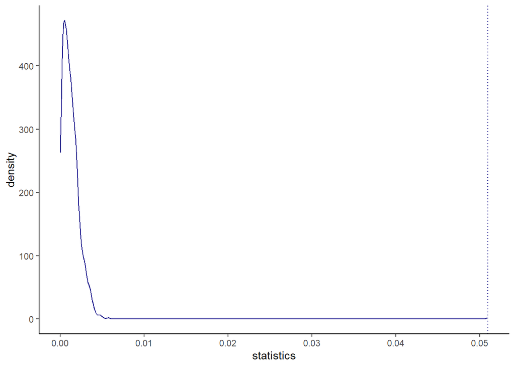